# SORC

[figure not shown]

Escola Secundária de Odivelas

Montar, instalar e manter equipamentos informáticos

Hardware do PC

Rui Fartaria · 2026/2027

## O que há dentro de um computador?

Hardware do PC Montar, instalar e manter equipamentos informáticos

No esquema:

1. **Monitor**  
   apresenta a informação ao utilizador
2. **Motherboard**  
   placa principal do computador
3. **CPU (microprocessador)**  
   executa instruções
4. **Conectores ATA**  
   permitem ligar unidades de armazenamento
5. **Memória principal (RAM)**  
   guarda temporariamente dados e programas em utilização
6. **Placas de expansão**  
   acrescentam funcionalidades ao computador

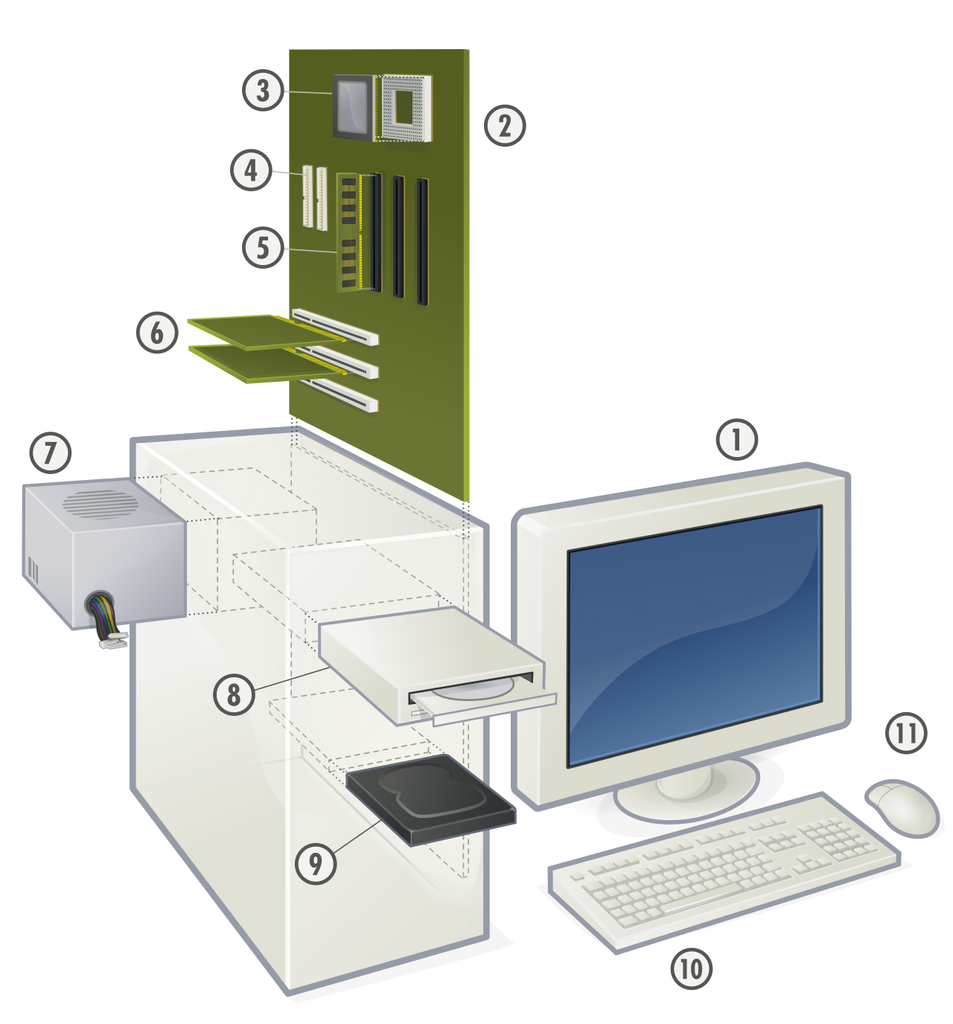

Esquema dos componentes de um computador

## O que há dentro de um computador?

Hardware do PC Montar, instalar e manter equipamentos informáticos

No esquema:

7. **Fonte de alimentação**  
   fornece energia aos componentes
8. **Unidade ótica**  
   lê e grava discos óticos
9. **Disco rígido (HDD)**  
   guarda dados de forma persistente
10. **Teclado**  
    dispositivo de entrada
11. **Rato**  
    dispositivo de entrada

Os componentes têm funções diferentes, mas trabalham em conjunto como parte do mesmo sistema.

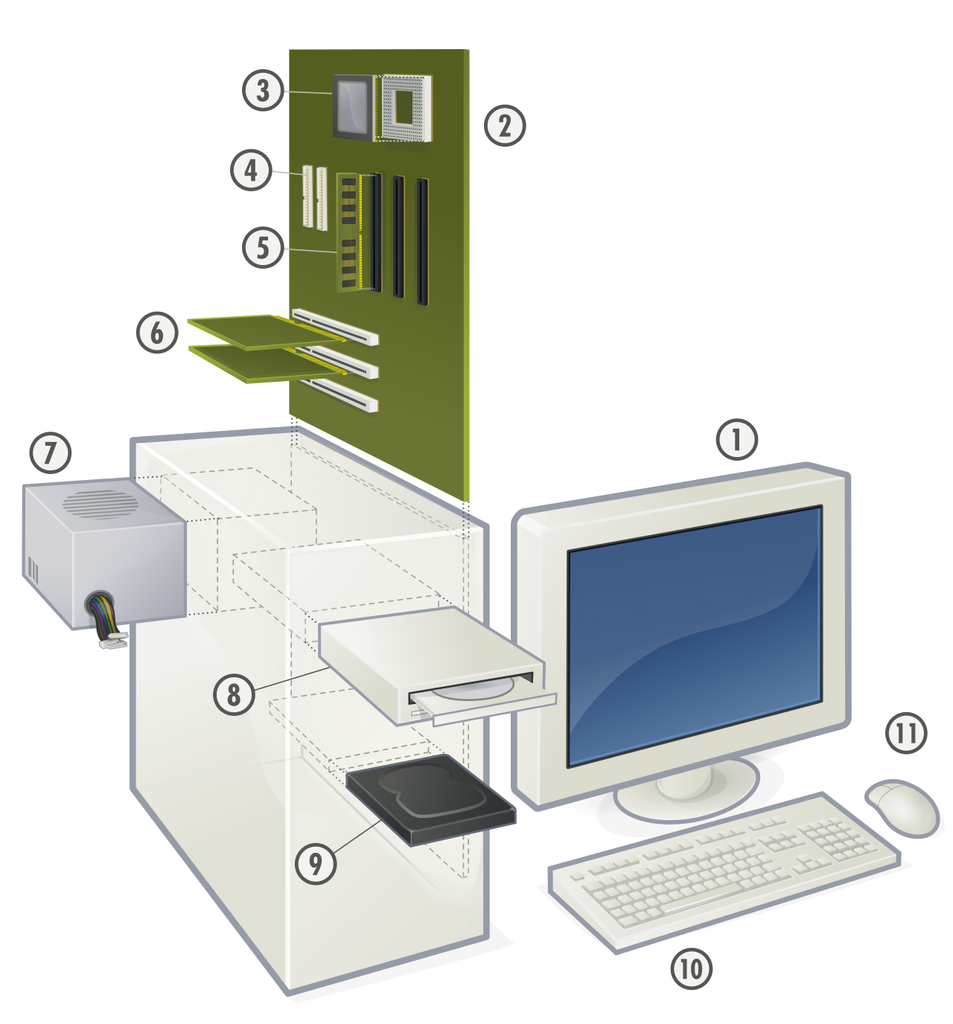

Esquema dos componentes de um computador

## E num computador real?

Hardware do PC Montar, instalar e manter equipamentos informáticos

Num computador real, os componentes aparecem:

- montados na **caixa**;
- ligados por **cabos e conectores**;
- parcialmente **escondidos**;
- com diferentes tamanhos e disposições.

O aspeto real é mais complexo do que num esquema.

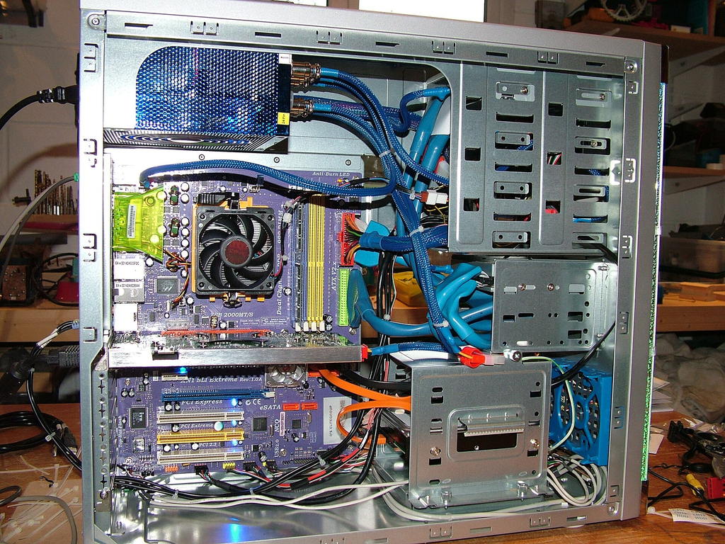

Interior de um computador de secretária

## Consegues localizar os componentes?

Hardware do PC Montar, instalar e manter equipamentos informáticos

Procura na fotografia:

- **motherboard**
- **CPU**
- **memória RAM**
- **armazenamento**
- **fonte de alimentação**
- **placas de expansão**

Não é necessário conhecer ainda todos os detalhes — primeiro vamos aprender a **reconhecer** os componentes.

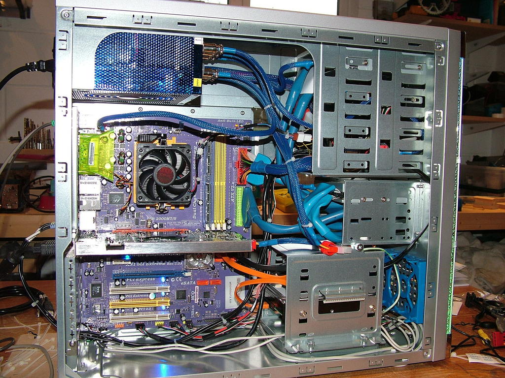

Que componentes consegues identificar?

## A motherboard

Hardware do PC Montar, instalar e manter equipamentos informáticos

[figure not shown]

## ASUS PRIME B650-PLUS

Hardware do PC Montar, instalar e manter equipamentos informáticos

[figure not shown]

## Esquema da motherboard

Hardware do PC Montar, instalar e manter equipamentos informáticos

[figure not shown]

## Elementos principais da motherboard

Hardware do PC Montar, instalar e manter equipamentos informáticos

A motherboard concentra as ligações principais do computador: **processamento, memória, expansão, armazenamento, alimentação e ligação à caixa**.

## CPU — o processador

Hardware do PC Montar, instalar e manter equipamentos informáticos

[figure not shown]

A **CPU** (*Central Processing Unit*):

- interpreta e executa instruções;
- realiza grande parte do processamento;
- é instalada num **socket** da motherboard.

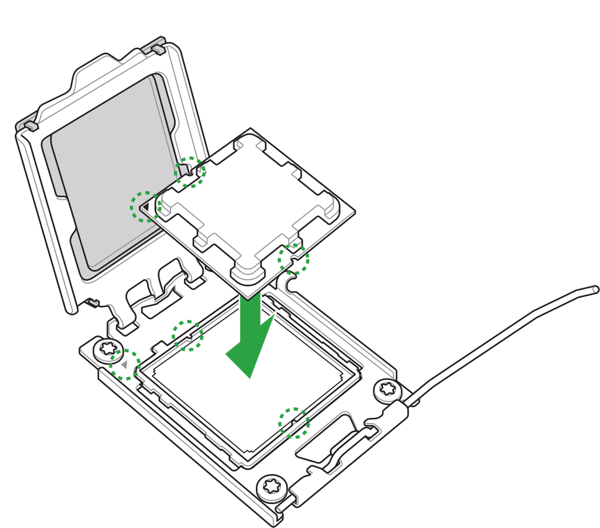

**CPU → socket → motherboard**

O processador tem de ser compatível com o socket da motherboard.

## Memória RAM

Hardware do PC Montar, instalar e manter equipamentos informáticos

A **memória RAM**:

- guarda temporariamente dados e programas em utilização;
- é **volátil** — perde o conteúdo quando o computador é desligado;
- funciona como memória de trabalho do sistema;
- é instalada nos **slots DIMM** da motherboard.

**RAM = memória de trabalho temporária**  
**SSD/HDD = armazenamento persistente**

[figure not shown]

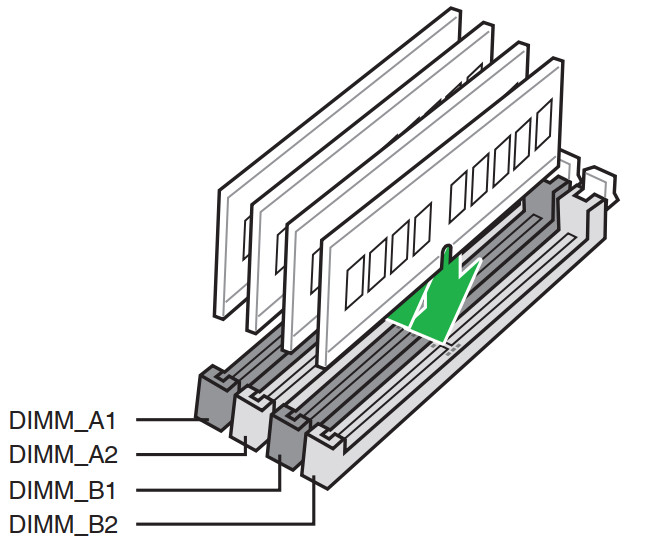

## Armazenamento — HDD e SSD

Hardware do PC Montar, instalar e manter equipamentos informáticos

### HDD

- armazenamento **magnético**;
- utiliza discos e outras **partes móveis**;
- guarda dados de forma **persistente**.

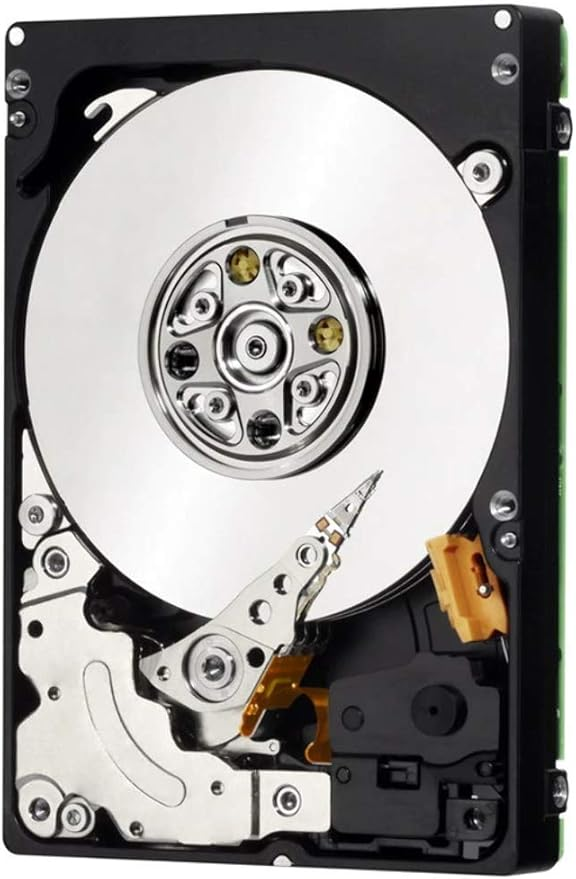

### SSD

- utiliza memória **flash**;
- não possui partes móveis;
- guarda dados de forma **persistente**.

[figure not shown]

## Formatos de armazenamento

Hardware do PC Montar, instalar e manter equipamentos informáticos

### HDD 3,5”

[figure not shown]

- comum em computadores de secretária;
- utiliza ligação SATA.

### SSD 2,5”

[figure not shown]

- formato semelhante a um pequeno disco;
- normalmente utiliza SATA.

### SSD M.2

[figure not shown]

- módulo compacto;
- instala-se diretamente na motherboard.

**Formato físico ≠ interface de comunicação.**

Um SSD M.2 pode utilizar diferentes interfaces.

## SATA, M.2 e NVMe

Hardware do PC Montar, instalar e manter equipamentos informáticos

**SATA**

**Interface de comunicação**

Liga dispositivos de armazenamento à motherboard.

Pode ser usada por HDD e SSD.

→

**M.2**

**Formato físico**

Define o formato e o encaixe de um módulo.

É muito utilizado em SSD.

→

**NVMe**

**Protocolo de comunicação**

Permite aos SSD comunicar através de **PCIe**.

**M.2 não significa necessariamente NVMe.**

O formato físico do dispositivo e a forma como comunica com o computador são conceitos diferentes.

## Como comunicam os componentes?

Hardware do PC Montar, instalar e manter equipamentos informáticos

A motherboard contém **barramentos** — caminhos que permitem transportar dados entre os diferentes componentes.

**CPU**

↔︎

**RAM**

↔︎

**Motherboard**

↔︎

**Armazenamento**

↔︎

**Placas de expansão**

Um **barramento** é uma via de comunicação que permite a troca de informação entre componentes.

## Slots de expansão — PCIe

Hardware do PC Montar, instalar e manter equipamentos informáticos

Os **slots de expansão** permitem acrescentar funcionalidades ao computador através de placas instaladas na motherboard.

Slots PCIe

- existem em diferentes comprimentos;
- ligam placas diretamente à motherboard;
- transportam dados através do barramento PCI Express.

→

Placas de expansão

Exemplos:

- placa gráfica;
- placa de rede;
- placa Wi-Fi;
- placa de som;
- placa de captura.

A placa de expansão tem de ser **compatível com o slot PCIe** onde será instalada.

## Placas de expansão

Hardware do PC Montar, instalar e manter equipamentos informáticos

As placas de expansão permitem acrescentar ou melhorar funcionalidades do computador.

Placa gráfica

Processa e gera a imagem enviada para o monitor.

Placa de rede

Permite ligar o computador a uma rede Ethernet.

Placa Wi-Fi

Acrescenta conectividade de rede sem fios.

Placa de captura

Recebe sinais de vídeo de outros dispositivos.

**Necessidade → placa de expansão → slot PCIe compatível**

## Dentro da caixa — dados e alimentação

Hardware do PC Montar, instalar e manter equipamentos informáticos

Os componentes internos precisam de **ligações diferentes** para comunicar e receber energia.

Cabos de dados

Transportam informação entre os componentes.

Exemplo:

- cabo **SATA de dados**;
- liga uma unidade SATA à motherboard.

≠

Cabos de alimentação

Fornecem energia aos componentes.

Exemplos:

- alimentação da motherboard;
- alimentação da CPU;
- alimentação SATA para unidades.

Um dispositivo pode precisar de **uma ligação de dados e outra de alimentação**.

## Portas e conectividade externa

Hardware do PC Montar, instalar e manter equipamentos informáticos

As portas externas permitem ligar o computador a **periféricos, redes e dispositivos de imagem e som**.

USB

Liga periféricos como **teclado, rato, armazenamento externo e impressoras**.

Vídeo

Liga monitores e outros equipamentos de imagem através de **HDMI** ou **DisplayPort**.

Rede

A porta **Ethernet** permite ligar o computador a uma rede através de cabo.

Áudio

Permite ligar **colunas, auscultadores e microfones**.

**Porta → tipo de ligação → dispositivo**

## USB — conectores e capacidades

Hardware do PC Montar, instalar e manter equipamentos informáticos

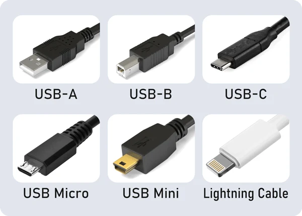

**Nota:** Lightning não é um conector USB.

Nem todas as ligações USB oferecem exatamente as mesmas funcionalidades.

Transferência de dados

Comunicação com periféricos e dispositivos de armazenamento.

Alimentação

Pode fornecer energia e carregar dispositivos.

Vídeo

Algumas portas **USB-C** podem também transportar sinal de vídeo.

O **formato do conector** não indica, por si só, todas as capacidades da porta.

## Ligações de vídeo — HDMI e DisplayPort

Hardware do PC Montar, instalar e manter equipamentos informáticos

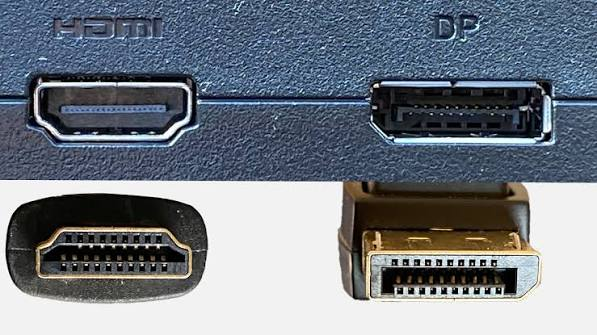

HDMI

Muito comum em **computadores, televisores e projetores**.

Transporta **vídeo e áudio**.

DisplayPort

Muito utilizado em **computadores e monitores**.

Transporta **vídeo e áudio**.

A placa gráfica ou a motherboard podem disponibilizar **diferentes tipos de saída de vídeo**.

## Ligação à rede — Ethernet

Hardware do PC Montar, instalar e manter equipamentos informáticos

A ligação Ethernet permite integrar o computador numa **rede local através de cabo**.

Conector RJ-45

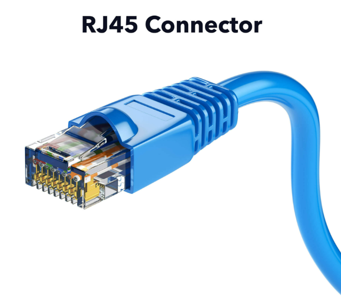

É utilizado na extremidade de muitos **cabos de rede Ethernet**.

Porta Ethernet

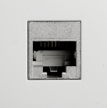

Recebe o conector RJ-45 e permite ligar o computador à rede.

Placa de rede

[figure not shown]

Pode estar integrada na motherboard ou instalada como **placa de expansão**.

**Cabo → conector RJ-45 → porta Ethernet → placa de rede**

## Ligações de áudio

Hardware do PC Montar, instalar e manter equipamentos informáticos

As ligações de áudio permitem ligar dispositivos de **entrada e saída de som** ao computador.

[figure not shown]

Saída de áudio

Liga dispositivos como **colunas e auscultadores**.

Entrada de áudio

Permite ligar **microfones e outras fontes de áudio**.

Placa de som

Pode estar integrada na motherboard ou instalada como **placa de expansão PCIe**.

As ligações de áudio podem servir para **entrada ou saída de som**.

## Periféricos — entrada, saída ou ambos?

Hardware do PC Montar, instalar e manter equipamentos informáticos

Os periféricos permitem ao computador **receber informação, apresentar resultados ou fazer as duas coisas**.

Entrada

Enviam informação para o computador.

Exemplos:

- teclado;
- rato;
- microfone;
- scanner.

Saída

Apresentam informação produzida pelo computador.

Exemplos:

- monitor;
- colunas;
- impressora.

Entrada e saída

Podem enviar e receber informação.

Exemplos:

- ecrã tátil;
- headset;
- dispositivo de armazenamento externo.

Classifica cada periférico pela **direção em que a informação circula**.

## Mapa do hardware do PC

Hardware do PC Montar, instalar e manter equipamentos informáticos

Os principais componentes podem ser organizados de acordo com a **função que desempenham no sistema**.

Processamento

**CPU**

Executa instruções e processa dados.

Memória

**RAM**

Guarda temporariamente dados e programas em utilização.

Armazenamento

**HDD / SSD**

Guardam dados de forma persistente.

Interligação

**Motherboard**

Liga e permite a comunicação entre os componentes.

Expansão

**PCIe / placas de expansão**

Acrescentam funcionalidades ao computador.

Entrada e saída

**Portas e periféricos**

Permitem a comunicação com utilizadores, redes e outros dispositivos.

O computador funciona como um **sistema de componentes interligados**, cada um com uma função específica.